# Linear Model Selection and Regularization

Kathy Lee

4/22/2021

**Load packages and dataset**

```r
library(dplyr)
library(leaps)

setwd("/Users/KathyLee/UCI MSBA/Course Material/05 Spring Quarter/BANA288 Predictive Analytics/Homework")
data <-  read.csv("hw3_vio_crime.csv")
```

**1. Prepare the data for analysis. The data set provided with this assignment has had columns removed from the 128, so that it begins with 103 variables. After reading in the data exam the structure. There are several columns that, as factors, have many levels (>30). Remove columns 1, 2, and 3. Also, there is one other column that should be removed using the “>30” criteria. Use this set of columns as the “prepared data set” for the remainder of the assignment.**

```r
# Remove columns 1, 2, and 3
dat <- subset(data, select = -c(state, communityname, fold))
str(dat)
```

```
## 'data.frame':    1993 obs. of  100 variables:
##  $ population           : num  0.19 0 0 0.04 0.01 0.02 0.01 0.01 0.03 0.01 ...
##  $ householdsize        : num  0.33 0.16 0.42 0.77 0.55 0.28 0.39 0.74 0.34 0.4 ...
##  $ racepctblack         : num  0.02 0.12 0.49 1 0.02 0.06 0 0.03 0.2 0.06 ...
##  $ racePctWhite         : num  0.9 0.74 0.56 0.08 0.95 0.54 0.98 0.46 0.84 0.87 ...
##  $ racePctAsian         : num  0.12 0.45 0.17 0.12 0.09 1 0.06 0.2 0.02 0.3 ...
##  $ racePctHisp          : num  0.17 0.07 0.04 0.1 0.05 0.25 0.02 1 0 0.03 ...
##  $ agePct12t21          : num  0.34 0.26 0.39 0.51 0.38 0.31 0.3 0.52 0.38 0.9 ...
##  $ agePct12t29          : num  0.47 0.59 0.47 0.5 0.38 0.48 0.37 0.55 0.45 0.82 ...
##  $ agePct16t24          : num  0.29 0.35 0.28 0.34 0.23 0.27 0.23 0.36 0.28 0.8 ...
##  $ agePct65up           : num  0.32 0.27 0.32 0.21 0.36 0.37 0.6 0.35 0.48 0.39 ...
##  $ numbUrban            : num  0.2 0.02 0 0.06 0.02 0.04 0.02 0 0.04 0.02 ...
##  $ pctUrban             : num  1 1 0 1 0.9 1 0.81 0 1 1 ...
##  $ medIncome            : num  0.37 0.31 0.3 0.58 0.5 0.52 0.42 0.16 0.17 0.54 ...
##  $ pctWWage             : num  0.72 0.72 0.58 0.89 0.72 0.68 0.5 0.44 0.47 0.59 ...
```

[output cut: 86 more lines]

**2. Use the entire prepared data set for this part. Can we perform best subsets regression to pick a “good” model? Why or why not? Explain what is happening.**

```r
#best <- regsubsets(VioCrime ~ ., dat)
#summary(best)
```

- It is not suggested to perform best subsets regression on datasets with many variables. This may lead to overfitting and high variance of the coefficient estimates. When trying to perform best subsets regression, it shows error that the exhaustive search will be slow.

**3. Use the entire prepared data set for this part. Perform forward stepwise regression to pick a “good” model by evaluating adjusted R-squared, Mallows Cp, and BIC. How many variables were in the models was selected using these criteria?**

```r
step <- regsubsets(VioCrime ~ ., dat, nvmax = 100, method = "forward")
step.sum <- summary(step)
```

**Plot adjusted R-squared, Mallows Cp, and BIC to evaluate**

```r
par(mfrow=c(2,2))

# Adjusted R-squared
plot(step.sum$rsq, xlab = "Number of Variables", ylab ="R-squared")
plot(step.sum$adjr2, xlab = "Number of Variables",
     ylab ="Adj R-squared")
which.max(step.sum$adjr2)
```

```
## [1] 64
```

```r
# Mallows Cp
maxar2 <- which.max(step.sum$adjr2)
points(maxar2, step.sum$adjr2[maxar2], col = "red", cex = 2, pch = 20)
plot(step.sum$cp, xlab = "Number of Variables", ylab ="Mallows Cp")
mincp <- which.min(step.sum$cp)
mincp
```

```
## [1] 51
```

```r
# BIC
points(mincp, step.sum$cp[mincp], col = "blue", cex = 2, pch = 20)
plot(step.sum$bic, xlab = "Number of Variables",
     ylab ="Bayesian Info Crit")
minbic <- which.min(step.sum$bic)
minbic
```

```
## [1] 15
```

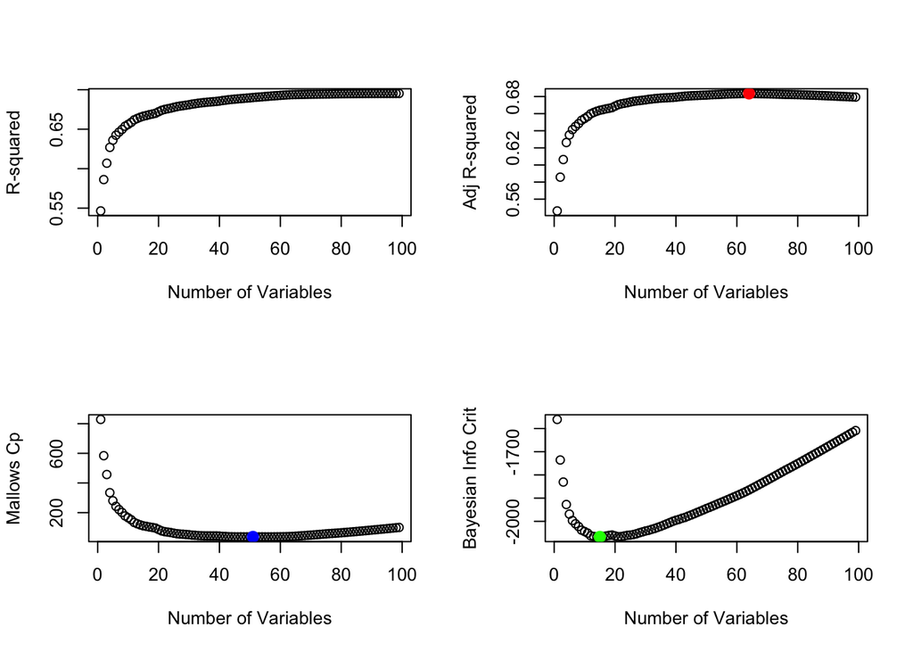

```r
points(minbic, step.sum$bic[minbic], col = "green", cex = 2, pch = 20)
```

- According to the result of adjusted R-squared, Mallows Cp, and BIC, 64, 51, and 15 variables were selected respectively.

**Run models on suggested variables**

```r
names(coef(step, 64))
```

```
##  [1] "(Intercept)"           "racepctblack"          "racePctWhite"
##  [4] "racePctHisp"           "agePct12t29"           "agePct16t24"
##  [7] "numbUrban"             "pctUrban"              "medIncome"
## [10] "pctWWage"              "pctWFarmSelf"          "pctWInvInc"
## [13] "pctWSocSec"            "pctWRetire"            "medFamInc"
## [16] "whitePerCap"           "blackPerCap"           "indianPerCap"
## [19] "AsianPerCap"           "OtherPerCap"           "HispPerCap"
## [22] "PctPopUnderPov"        "PctLess9thGrade"       "PctBSorMore"
## [25] "PctEmploy"             "PctEmplManu"           "PctOccupManu"
## [28] "PctOccupMgmtProf"      "MalePctDivorce"        "MalePctNevMarr"
## [31] "FemalePctDiv"          "TotalPctDiv"           "PctKids2Par"
## [34] "PctWorkMomYoungKids"   "PctWorkMom"            "NumIlleg"
## [37] "PctIlleg"              "NumImmig"              "PctSpeakEnglOnly"
## [40] "PctNotSpeakEnglWell"   "PctLargHouseOccup"     "PersPerOccupHous"
## [43] "PersPerRentOccHous"    "PctPersOwnOccup"       "PctPersDenseHous"
## [46] "PctHousLess3BR"        "MedNumBR"              "HousVacant"
## [49] "PctHousOccup"          "PctHousOwnOcc"         "PctVacantBoarded"
## [52] "PctVacMore6Mos"        "OwnOccLowQuart"        "OwnOccMedVal"
## [55] "RentLowQ"              "RentHighQ"             "MedRent"
## [58] "MedRentPctHousInc"     "MedOwnCostPctInc"      "MedOwnCostPctIncNoMtg"
## [61] "NumInShelters"         "NumStreet"             "PctForeignBorn"
## [64] "PctSameCity85"         "PctUsePubTrans"
```

```r
# mod.rsq1 (64 variables)
mod.rsq1 <- lm(VioCrime ~ racepctblack + racePctWhite + racePctHisp + agePct12t29 + agePct16t24 + numbUrban + pctUrban + medIncome + pctWWage +  pctWFarmSelf + pctWInvInc + pctWSocSec + pctWRetire + medFamInc + whitePerCap + blackPerCap + indianPerCap + AsianPerCap + OtherPerCap + HispPerCap +  PctPopUnderPov + PctLess9thGrade + PctBSorMore + PctEmploy + PctEmplManu + PctOccupManu + PctOccupMgmtProf + MalePctDivorce + MalePctNevMarr + FemalePctDiv + TotalPctDiv + PctKids2Par + PctWorkMomYoungKids + PctWorkMom + NumIlleg + PctIlleg + NumImmig + PctSpeakEnglOnly + PctNotSpeakEnglWell +  PctLargHouseOccup + PersPerOccupHous + PersPerRentOccHous + PctPersOwnOccup + PctPersDenseHous + PctHousLess3BR + MedNumBR + HousVacant + PctHousOccup + PctHousOwnOcc + PctVacantBoarded + PctVacMore6Mos + OwnOccLowQuart + OwnOccMedVal + RentLowQ + RentHighQ + MedRent + MedRentPctHousInc + MedOwnCostPctInc + MedOwnCostPctIncNoMtg + NumInShelters + NumStreet + PctForeignBorn + PctSameCity85 + PctUsePubTrans, data = dat)
summary(mod.rsq1)
```

```
##
## Call:
## lm(formula = VioCrime ~ racepctblack + racePctWhite + racePctHisp +
##     agePct12t29 + agePct16t24 + numbUrban + pctUrban + medIncome +
##     pctWWage + pctWFarmSelf + pctWInvInc + pctWSocSec + pctWRetire +
##     medFamInc + whitePerCap + blackPerCap + indianPerCap + AsianPerCap +
##     OtherPerCap + HispPerCap + PctPopUnderPov + PctLess9thGrade +
##     PctBSorMore + PctEmploy + PctEmplManu + PctOccupManu + PctOccupMgmtProf +
##     MalePctDivorce + MalePctNevMarr + FemalePctDiv + TotalPctDiv +
##     PctKids2Par + PctWorkMomYoungKids + PctWorkMom + NumIlleg +
##     PctIlleg + NumImmig + PctSpeakEnglOnly + PctNotSpeakEnglWell +
##     PctLargHouseOccup + PersPerOccupHous + PersPerRentOccHous +
##     PctPersOwnOccup + PctPersDenseHous + PctHousLess3BR + MedNumBR +
##     HousVacant + PctHousOccup + PctHousOwnOcc + PctVacantBoarded +
##     PctVacMore6Mos + OwnOccLowQuart + OwnOccMedVal + RentLowQ +
##     RentHighQ + MedRent + MedRentPctHousInc + MedOwnCostPctInc +
##     MedOwnCostPctIncNoMtg + NumInShelters + NumStreet + PctForeignBorn +
##     PctSameCity85 + PctUsePubTrans, data = dat)
##
## Residuals:
##      Min       1Q   Median       3Q      Max
## -0.51233 -0.07092 -0.01483  0.05052  0.72399
##
## Coefficients:
##                        Estimate Std. Error t value Pr(>|t|)
## (Intercept)            0.556139   0.160388   3.467 0.000537 ***
## racepctblack           0.197223   0.045493   4.335 1.53e-05 ***
## racePctWhite          -0.030628   0.048202  -0.635 0.525243
## racePctHisp            0.064081   0.046589   1.375 0.169150
## agePct12t29           -0.314938   0.135625  -2.322 0.020330 *
## agePct16t24            0.041403   0.094437   0.438 0.661127
## numbUrban             -0.045599   0.098416  -0.463 0.643177
## pctUrban               0.039156   0.009778   4.004 6.45e-05 ***
## medIncome             -0.199839   0.165705  -1.206 0.227968
## pctWWage              -0.209386   0.077773  -2.692 0.007158 **
## pctWFarmSelf           0.046447   0.019236   2.415 0.015847 *
## pctWInvInc            -0.174211   0.062913  -2.769 0.005675 **
## pctWSocSec             0.105005   0.077437   1.356 0.175256
## pctWRetire            -0.090662   0.033535  -2.704 0.006921 **
## medFamInc              0.318996   0.147972   2.156 0.031224 *
```

[output cut: 41 more lines]

```
## MedRent                0.362685   0.097121   3.734 0.000194 ***
## MedRentPctHousInc      0.041599   0.031407   1.325 0.185494
## MedOwnCostPctInc      -0.043595   0.031826  -1.370 0.170920
## MedOwnCostPctIncNoMtg -0.081212   0.023214  -3.498 0.000479 ***
## NumInShelters          0.128108   0.062679   2.044 0.041102 *
## NumStreet              0.177207   0.046085   3.845 0.000124 ***
## PctForeignBorn         0.127889   0.052362   2.442 0.014678 *
## PctSameCity85          0.038949   0.029255   1.331 0.183234
## PctUsePubTrans        -0.044186   0.021079  -2.096 0.036196 *
## ---
## Signif. codes:  0 '***' 0.001 '**' 0.01 '*' 0.05 '.' 0.1 ' ' 1
##
## Residual standard error: 0.1311 on 1928 degrees of freedom
## Multiple R-squared:  0.6938, Adjusted R-squared:  0.6836
## F-statistic: 68.26 on 64 and 1928 DF,  p-value: < 2.2e-16
```

```r
names(coef(step, 51))
```

```
##  [1] "(Intercept)"           "racepctblack"          "racePctWhite"
##  [4] "agePct12t29"           "agePct16t24"           "numbUrban"
##  [7] "pctUrban"              "medIncome"             "pctWWage"
## [10] "pctWFarmSelf"          "pctWInvInc"            "pctWRetire"
## [13] "medFamInc"             "whitePerCap"           "indianPerCap"
## [16] "AsianPerCap"           "OtherPerCap"           "HispPerCap"
## [19] "PctPopUnderPov"        "PctLess9thGrade"       "PctBSorMore"
## [22] "PctEmploy"             "PctEmplManu"           "PctOccupManu"
## [25] "MalePctDivorce"        "MalePctNevMarr"        "FemalePctDiv"
## [28] "TotalPctDiv"           "PctKids2Par"           "PctWorkMom"
## [31] "PctIlleg"              "PctSpeakEnglOnly"      "PctNotSpeakEnglWell"
## [34] "PctLargHouseOccup"     "PersPerOccupHous"      "PersPerRentOccHous"
## [37] "PctPersOwnOccup"       "PctPersDenseHous"      "PctHousLess3BR"
## [40] "HousVacant"            "PctHousOwnOcc"         "PctVacantBoarded"
## [43] "PctVacMore6Mos"        "OwnOccLowQuart"        "RentLowQ"
## [46] "MedRent"               "MedRentPctHousInc"     "MedOwnCostPctInc"
## [49] "MedOwnCostPctIncNoMtg" "NumStreet"             "PctForeignBorn"
## [52] "PctUsePubTrans"
```

```r
# mod.mcp1 (51 variables)
mod.mcp1 <- lm(VioCrime ~ racepctblack + racePctWhite + agePct12t29 + agePct16t24 + numbUrban + pctUrban + medIncome + pctWWage + pctWFarmSelf + pctWInvInc + pctWRetire + medFamInc + whitePerCap + indianPerCap + AsianPerCap + OtherPerCap + HispPerCap + PctPopUnderPov + PctLess9thGrade + PctBSorMore + PctEmploy + PctEmplManu + PctOccupManu + MalePctDivorce + MalePctNevMarr + FemalePctDiv + TotalPctDiv + PctKids2Par + PctWorkMom + PctIlleg + PctSpeakEnglOnly + PctNotSpeakEnglWell + PctLargHouseOccup + PersPerOccupHous + PersPerRentOccHous + PctPersOwnOccup + PctPersDenseHous + PctHousLess3BR + HousVacant + PctHousOwnOcc + PctVacantBoarded + PctVacMore6Mos + OwnOccLowQuart + RentLowQ + MedRent + MedRentPctHousInc + MedOwnCostPctInc + MedOwnCostPctIncNoMtg + NumStreet + PctForeignBorn + PctUsePubTrans, data = dat)
summary(mod.mcp1) #0.6901
```

```
##
## Call:
## lm(formula = VioCrime ~ racepctblack + racePctWhite + agePct12t29 +
##     agePct16t24 + numbUrban + pctUrban + medIncome + pctWWage +
##     pctWFarmSelf + pctWInvInc + pctWRetire + medFamInc + whitePerCap +
##     indianPerCap + AsianPerCap + OtherPerCap + HispPerCap + PctPopUnderPov +
##     PctLess9thGrade + PctBSorMore + PctEmploy + PctEmplManu +
##     PctOccupManu + MalePctDivorce + MalePctNevMarr + FemalePctDiv +
##     TotalPctDiv + PctKids2Par + PctWorkMom + PctIlleg + PctSpeakEnglOnly +
##     PctNotSpeakEnglWell + PctLargHouseOccup + PersPerOccupHous +
##     PersPerRentOccHous + PctPersOwnOccup + PctPersDenseHous +
##     PctHousLess3BR + HousVacant + PctHousOwnOcc + PctVacantBoarded +
##     PctVacMore6Mos + OwnOccLowQuart + RentLowQ + MedRent + MedRentPctHousInc +
##     MedOwnCostPctInc + MedOwnCostPctIncNoMtg + NumStreet + PctForeignBorn +
##     PctUsePubTrans, data = dat)
##
## Residuals:
##      Min       1Q   Median       3Q      Max
## -0.50682 -0.07084 -0.01462  0.04963  0.73912
##
## Coefficients:
##                        Estimate Std. Error t value Pr(>|t|)
## (Intercept)            0.779718   0.130788   5.962 2.96e-09 ***
## racepctblack           0.182138   0.043599   4.178 3.08e-05 ***
## racePctWhite          -0.036909   0.046669  -0.791 0.429117
## agePct12t29           -0.343286   0.130540  -2.630 0.008613 **
## agePct16t24            0.054760   0.092725   0.591 0.554885
## numbUrban             -0.172711   0.064830  -2.664 0.007784 **
## pctUrban               0.043471   0.009184   4.733 2.37e-06 ***
## medIncome             -0.280948   0.161691  -1.738 0.082448 .
## pctWWage              -0.288705   0.062186  -4.643 3.67e-06 ***
## pctWFarmSelf           0.048501   0.019163   2.531 0.011454 *
## pctWInvInc            -0.192881   0.061342  -3.144 0.001690 **
## pctWRetire            -0.092066   0.032727  -2.813 0.004955 **
## medFamInc              0.340115   0.145389   2.339 0.019419 *
## whitePerCap           -0.189866   0.071871  -2.642 0.008314 **
## indianPerCap          -0.036758   0.019073  -1.927 0.054096 .
## AsianPerCap            0.030327   0.018195   1.667 0.095721 .
## OtherPerCap            0.042647   0.018334   2.326 0.020113 *
## HispPerCap             0.032843   0.024052   1.366 0.172248
```

[output cut: 25 more lines]

```
## OwnOccLowQuart        -0.074528   0.045712  -1.630 0.103181
## RentLowQ              -0.221396   0.055017  -4.024 5.94e-05 ***
## MedRent                0.269750   0.071775   3.758 0.000176 ***
## MedRentPctHousInc      0.025806   0.030517   0.846 0.397858
## MedOwnCostPctInc      -0.050446   0.029965  -1.684 0.092437 .
## MedOwnCostPctIncNoMtg -0.074220   0.022571  -3.288 0.001026 **
## NumStreet              0.178385   0.040218   4.435 9.70e-06 ***
## PctForeignBorn         0.074757   0.046410   1.611 0.107388
## PctUsePubTrans        -0.044925   0.020601  -2.181 0.029321 *
## ---
## Signif. codes:  0 '***' 0.001 '**' 0.01 '*' 0.05 '.' 0.1 ' ' 1
##
## Residual standard error: 0.1314 on 1941 degrees of freedom
## Multiple R-squared:  0.6901, Adjusted R-squared:  0.682
## F-statistic: 84.76 on 51 and 1941 DF,  p-value: < 2.2e-16
```

```r
names(coef(step, 15))
```

```
##  [1] "(Intercept)"           "racepctblack"          "racePctWhite"
##  [4] "agePct12t29"           "numbUrban"             "pctUrban"
##  [7] "OtherPerCap"           "MalePctDivorce"        "FemalePctDiv"
## [10] "PctKids2Par"           "PctWorkMom"            "PctIlleg"
## [13] "PctPersDenseHous"      "HousVacant"            "MedOwnCostPctIncNoMtg"
## [16] "NumStreet"
```

```r
# mod.bic1 (15 variables)
mod.bic1 <- lm(VioCrime ~ racepctblack + racePctWhite + agePct12t29 + numbUrban + pctUrban + OtherPerCap + MalePctDivorce + FemalePctDiv + PctKids2Par + PctWorkMom + PctIlleg + PctPersDenseHous + HousVacant + MedOwnCostPctIncNoMtg + NumStreet, data = dat)
summary(mod.bic1) #0.6665
```

```
##
## Call:
## lm(formula = VioCrime ~ racepctblack + racePctWhite + agePct12t29 +
##     numbUrban + pctUrban + OtherPerCap + MalePctDivorce + FemalePctDiv +
##     PctKids2Par + PctWorkMom + PctIlleg + PctPersDenseHous +
##     HousVacant + MedOwnCostPctIncNoMtg + NumStreet, data = dat)
##
## Residuals:
##      Min       1Q   Median       3Q      Max
## -0.52340 -0.07182 -0.01528  0.04803  0.79155
##
## Coefficients:
##                        Estimate Std. Error t value Pr(>|t|)
## (Intercept)            0.349596   0.063551   5.501 4.27e-08 ***
## racepctblack           0.156815   0.036198   4.332 1.55e-05 ***
## racePctWhite          -0.031108   0.041315  -0.753 0.451573
## agePct12t29           -0.085176   0.024482  -3.479 0.000514 ***
## numbUrban             -0.232185   0.061249  -3.791 0.000155 ***
## pctUrban               0.042788   0.007779   5.501 4.28e-08 ***
## OtherPerCap            0.047909   0.017110   2.800 0.005159 **
## MalePctDivorce         0.166182   0.049088   3.385 0.000725 ***
## FemalePctDiv          -0.065177   0.051159  -1.274 0.202810
## PctKids2Par           -0.314220   0.044519  -7.058 2.33e-12 ***
## PctWorkMom            -0.082234   0.019665  -4.182 3.02e-05 ***
## PctIlleg               0.200797   0.036819   5.454 5.56e-08 ***
## PctPersDenseHous       0.191815   0.031070   6.174 8.07e-10 ***
## HousVacant             0.299080   0.048279   6.195 7.08e-10 ***
## MedOwnCostPctIncNoMtg -0.056238   0.017584  -3.198 0.001404 **
## NumStreet              0.203305   0.040282   5.047 4.90e-07 ***
## ---
## Signif. codes:  0 '***' 0.001 '**' 0.01 '*' 0.05 '.' 0.1 ' ' 1
##
## Residual standard error: 0.1351 on 1977 degrees of freedom
## Multiple R-squared:  0.6665, Adjusted R-squared:  0.664
## F-statistic: 263.4 on 15 and 1977 DF,  p-value: < 2.2e-16
```

```r
anova(mod.mcp1, mod.rsq1)
```

```
## Analysis of Variance Table
##
## Model 1: VioCrime ~ racepctblack + racePctWhite + agePct12t29 + agePct16t24 +
##     numbUrban + pctUrban + medIncome + pctWWage + pctWFarmSelf +
##     pctWInvInc + pctWRetire + medFamInc + whitePerCap + indianPerCap +
##     AsianPerCap + OtherPerCap + HispPerCap + PctPopUnderPov +
##     PctLess9thGrade + PctBSorMore + PctEmploy + PctEmplManu +
##     PctOccupManu + MalePctDivorce + MalePctNevMarr + FemalePctDiv +
##     TotalPctDiv + PctKids2Par + PctWorkMom + PctIlleg + PctSpeakEnglOnly +
##     PctNotSpeakEnglWell + PctLargHouseOccup + PersPerOccupHous +
##     PersPerRentOccHous + PctPersOwnOccup + PctPersDenseHous +
##     PctHousLess3BR + HousVacant + PctHousOwnOcc + PctVacantBoarded +
##     PctVacMore6Mos + OwnOccLowQuart + RentLowQ + MedRent + MedRentPctHousInc +
##     MedOwnCostPctInc + MedOwnCostPctIncNoMtg + NumStreet + PctForeignBorn +
##     PctUsePubTrans
## Model 2: VioCrime ~ racepctblack + racePctWhite + racePctHisp + agePct12t29 +
##     agePct16t24 + numbUrban + pctUrban + medIncome + pctWWage +
##     pctWFarmSelf + pctWInvInc + pctWSocSec + pctWRetire + medFamInc +
##     whitePerCap + blackPerCap + indianPerCap + AsianPerCap +
##     OtherPerCap + HispPerCap + PctPopUnderPov + PctLess9thGrade +
##     PctBSorMore + PctEmploy + PctEmplManu + PctOccupManu + PctOccupMgmtProf +
##     MalePctDivorce + MalePctNevMarr + FemalePctDiv + TotalPctDiv +
##     PctKids2Par + PctWorkMomYoungKids + PctWorkMom + NumIlleg +
##     PctIlleg + NumImmig + PctSpeakEnglOnly + PctNotSpeakEnglWell +
##     PctLargHouseOccup + PersPerOccupHous + PersPerRentOccHous +
##     PctPersOwnOccup + PctPersDenseHous + PctHousLess3BR + MedNumBR +
##     HousVacant + PctHousOccup + PctHousOwnOcc + PctVacantBoarded +
##     PctVacMore6Mos + OwnOccLowQuart + OwnOccMedVal + RentLowQ +
##     RentHighQ + MedRent + MedRentPctHousInc + MedOwnCostPctInc +
##     MedOwnCostPctIncNoMtg + NumInShelters + NumStreet + PctForeignBorn +
##     PctSameCity85 + PctUsePubTrans
##   Res.Df    RSS Df Sum of Sq      F  Pr(>F)
## 1   1941 33.524
## 2   1928 33.127 13   0.39732 1.7788 0.04106 *
## ---
## Signif. codes:  0 '***' 0.001 '**' 0.01 '*' 0.05 '.' 0.1 ' ' 1
```

```r
anova(mod.bic1, mod.mcp1)
```

```
## Analysis of Variance Table
##
## Model 1: VioCrime ~ racepctblack + racePctWhite + agePct12t29 + numbUrban +
##     pctUrban + OtherPerCap + MalePctDivorce + FemalePctDiv +
##     PctKids2Par + PctWorkMom + PctIlleg + PctPersDenseHous +
##     HousVacant + MedOwnCostPctIncNoMtg + NumStreet
## Model 2: VioCrime ~ racepctblack + racePctWhite + agePct12t29 + agePct16t24 +
##     numbUrban + pctUrban + medIncome + pctWWage + pctWFarmSelf +
##     pctWInvInc + pctWRetire + medFamInc + whitePerCap + indianPerCap +
##     AsianPerCap + OtherPerCap + HispPerCap + PctPopUnderPov +
##     PctLess9thGrade + PctBSorMore + PctEmploy + PctEmplManu +
##     PctOccupManu + MalePctDivorce + MalePctNevMarr + FemalePctDiv +
##     TotalPctDiv + PctKids2Par + PctWorkMom + PctIlleg + PctSpeakEnglOnly +
##     PctNotSpeakEnglWell + PctLargHouseOccup + PersPerOccupHous +
##     PersPerRentOccHous + PctPersOwnOccup + PctPersDenseHous +
##     PctHousLess3BR + HousVacant + PctHousOwnOcc + PctVacantBoarded +
##     PctVacMore6Mos + OwnOccLowQuart + RentLowQ + MedRent + MedRentPctHousInc +
##     MedOwnCostPctInc + MedOwnCostPctIncNoMtg + NumStreet + PctForeignBorn +
##     PctUsePubTrans
##   Res.Df    RSS Df Sum of Sq      F    Pr(>F)
## 1   1977 36.077
## 2   1941 33.524 36    2.5531 4.1061 8.299e-15 ***
## ---
## Signif. codes:  0 '***' 0.001 '**' 0.01 '*' 0.05 '.' 0.1 ' ' 1
```

**4. Repeat question 3 for backward stepwise regression. Is a “good” model in backward different from forward stepwise? Explain. Summarize what stepwise regression is providing.**

```r
step2 <- regsubsets(VioCrime ~ ., dat, nvmax = 99, method = "backward")
step2.sum <- summary(step2)
```

**Plot adjusted R-squared, Mallows Cp, and BIC to evaluate**

```r
par(mfrow=c(2,2))

plot(step2.sum$rsq, xlab = "Number of Variables", ylab ="R-squared")
plot(step2.sum$adjr2, xlab = "Number of Variables",
     ylab ="Adj R-squared")
maxar2 <- which.max(step2.sum$adjr2)
maxar2
```

```
## [1] 58
```

```r
points(maxar2, step2.sum$adjr2[maxar2], col = "red", cex = 2, pch = 20)

plot(step2.sum$cp, xlab = "Number of Variables", ylab ="Mallows Cp")
mincp <- which.min(step2.sum$cp)
mincp
```

```
## [1] 49
```

```r
points(mincp, step2.sum$cp[mincp], col = "blue", cex = 2, pch = 20)

plot(step2.sum$bic, xlab = "Number of Variables",
     ylab ="Bayesian Info Crit")
minbic <- which.min(step2.sum$bic)
minbic
```

```
## [1] 14
```

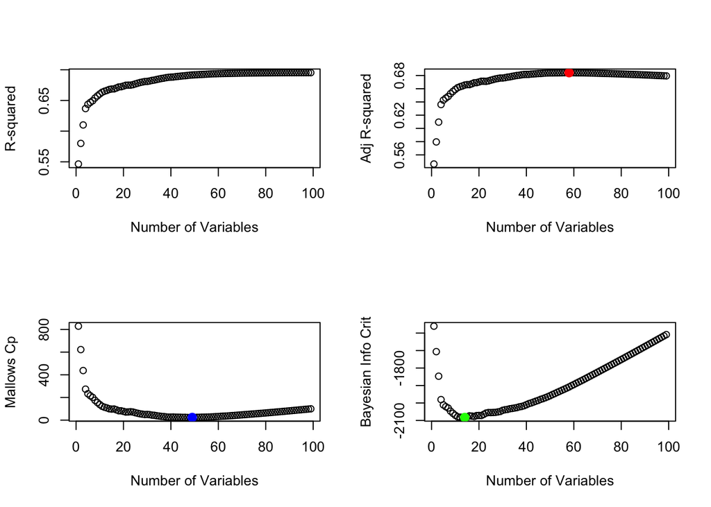

```r
points(minbic, step2.sum$bic[minbic], col = "green", cex = 2, pch = 20)
```

```r
names(coef(step2, 58))
```

```
##  [1] "(Intercept)"           "racepctblack"          "racePctHisp"
##  [4] "agePct12t29"           "pctUrban"              "medIncome"
##  [7] "pctWWage"              "pctWFarmSelf"          "pctWInvInc"
## [10] "pctWSocSec"            "pctWRetire"            "medFamInc"
## [13] "whitePerCap"           "blackPerCap"           "indianPerCap"
## [16] "AsianPerCap"           "OtherPerCap"           "HispPerCap"
## [19] "PctPopUnderPov"        "PctLess9thGrade"       "PctEmploy"
## [22] "PctEmplManu"           "PctOccupManu"          "PctOccupMgmtProf"
## [25] "MalePctDivorce"        "MalePctNevMarr"        "TotalPctDiv"
## [28] "PctKids2Par"           "PctWorkMomYoungKids"   "PctWorkMom"
## [31] "NumIlleg"              "PctIlleg"              "NumImmig"
## [34] "PctNotSpeakEnglWell"   "PctLargHouseOccup"     "PersPerOccupHous"
## [37] "PersPerRentOccHous"    "PctPersOwnOccup"       "PctPersDenseHous"
## [40] "PctHousLess3BR"        "MedNumBR"              "HousVacant"
## [43] "PctHousOccup"          "PctHousOwnOcc"         "PctVacantBoarded"
## [46] "PctVacMore6Mos"        "OwnOccLowQuart"        "OwnOccMedVal"
## [49] "RentLowQ"              "RentHighQ"             "MedRent"
## [52] "MedRentPctHousInc"     "MedOwnCostPctInc"      "MedOwnCostPctIncNoMtg"
## [55] "NumInShelters"         "NumStreet"             "PctForeignBorn"
## [58] "PctSameCity85"         "PctUsePubTrans"
```

```r
mod.rsq2 <- lm(VioCrime ~ racepctblack + racePctHisp + agePct12t29 + pctUrban + medIncome + pctWWage + pctWFarmSelf + pctWInvInc + pctWSocSec + pctWRetire + medFamInc + whitePerCap + blackPerCap + indianPerCap + AsianPerCap + OtherPerCap + HispPerCap + PctPopUnderPov + PctLess9thGrade + PctEmploy + PctEmplManu + PctOccupManu + PctOccupMgmtProf + MalePctDivorce + MalePctNevMarr + TotalPctDiv + PctKids2Par + PctWorkMomYoungKids + PctWorkMom + NumIlleg + PctIlleg + NumImmig + PctNotSpeakEnglWell + PctLargHouseOccup + PersPerOccupHous + PersPerRentOccHous + PctPersOwnOccup + PctPersDenseHous + PctHousLess3BR + MedNumBR + HousVacant + PctHousOccup + PctHousOwnOcc + PctVacantBoarded + PctVacMore6Mos + OwnOccLowQuart  + OwnOccMedVal + RentLowQ + RentHighQ + MedRent + MedRentPctHousInc + MedOwnCostPctInc + MedOwnCostPctIncNoMtg + NumInShelters + NumStreet + PctForeignBorn + PctSameCity85 + PctUsePubTrans, data = dat)
summary(mod.rsq2)
```

```
##
## Call:
## lm(formula = VioCrime ~ racepctblack + racePctHisp + agePct12t29 +
##     pctUrban + medIncome + pctWWage + pctWFarmSelf + pctWInvInc +
##     pctWSocSec + pctWRetire + medFamInc + whitePerCap + blackPerCap +
##     indianPerCap + AsianPerCap + OtherPerCap + HispPerCap + PctPopUnderPov +
##     PctLess9thGrade + PctEmploy + PctEmplManu + PctOccupManu +
##     PctOccupMgmtProf + MalePctDivorce + MalePctNevMarr + TotalPctDiv +
##     PctKids2Par + PctWorkMomYoungKids + PctWorkMom + NumIlleg +
##     PctIlleg + NumImmig + PctNotSpeakEnglWell + PctLargHouseOccup +
##     PersPerOccupHous + PersPerRentOccHous + PctPersOwnOccup +
##     PctPersDenseHous + PctHousLess3BR + MedNumBR + HousVacant +
##     PctHousOccup + PctHousOwnOcc + PctVacantBoarded + PctVacMore6Mos +
##     OwnOccLowQuart + OwnOccMedVal + RentLowQ + RentHighQ + MedRent +
##     MedRentPctHousInc + MedOwnCostPctInc + MedOwnCostPctIncNoMtg +
##     NumInShelters + NumStreet + PctForeignBorn + PctSameCity85 +
##     PctUsePubTrans, data = dat)
##
## Residuals:
##      Min       1Q   Median       3Q      Max
## -0.52104 -0.07054 -0.01462  0.05006  0.72780
##
## Coefficients:
##                        Estimate Std. Error t value Pr(>|t|)
## (Intercept)            0.508932   0.144687   3.517 0.000446 ***
## racepctblack           0.217291   0.031172   6.971 4.31e-12 ***
## racePctHisp            0.081564   0.036866   2.212 0.027051 *
## agePct12t29           -0.270126   0.073645  -3.668 0.000251 ***
## pctUrban               0.037481   0.009096   4.121 3.94e-05 ***
## medIncome             -0.205184   0.164240  -1.249 0.211708
## pctWWage              -0.222214   0.076788  -2.894 0.003848 **
## pctWFarmSelf           0.047713   0.019173   2.488 0.012912 *
## pctWInvInc            -0.162031   0.060708  -2.669 0.007670 **
## pctWSocSec             0.089581   0.074949   1.195 0.232143
## pctWRetire            -0.088462   0.033052  -2.676 0.007504 **
## medFamInc              0.329169   0.142433   2.311 0.020935 *
## whitePerCap           -0.252422   0.075191  -3.357 0.000803 ***
## blackPerCap           -0.025718   0.024539  -1.048 0.294751
## indianPerCap          -0.035397   0.019064  -1.857 0.063507 .
## AsianPerCap            0.020648   0.018230   1.133 0.257508
```

[output cut: 34 more lines]

```
## MedRent                0.374451   0.096418   3.884 0.000106 ***
## MedRentPctHousInc      0.042269   0.031071   1.360 0.173856
## MedOwnCostPctInc      -0.043275   0.031713  -1.365 0.172547
## MedOwnCostPctIncNoMtg -0.084532   0.022791  -3.709 0.000214 ***
## NumInShelters          0.128557   0.061907   2.077 0.037969 *
## NumStreet              0.179034   0.045712   3.917 9.29e-05 ***
## PctForeignBorn         0.150034   0.044077   3.404 0.000678 ***
## PctSameCity85          0.034491   0.028598   1.206 0.227948
## PctUsePubTrans        -0.043841   0.020817  -2.106 0.035334 *
## ---
## Signif. codes:  0 '***' 0.001 '**' 0.01 '*' 0.05 '.' 0.1 ' ' 1
##
## Residual standard error: 0.1309 on 1934 degrees of freedom
## Multiple R-squared:  0.6935, Adjusted R-squared:  0.6843
## F-statistic: 75.43 on 58 and 1934 DF,  p-value: < 2.2e-16
```

```r
names(coef(step2, 49))
```

```
##  [1] "(Intercept)"           "racepctblack"          "racePctHisp"
##  [4] "agePct12t29"           "pctUrban"              "medIncome"
##  [7] "pctWWage"              "pctWFarmSelf"          "pctWInvInc"
## [10] "pctWRetire"            "medFamInc"             "whitePerCap"
## [13] "indianPerCap"          "OtherPerCap"           "HispPerCap"
## [16] "PctPopUnderPov"        "PctLess9thGrade"       "PctEmploy"
## [19] "PctEmplManu"           "PctOccupManu"          "PctOccupMgmtProf"
## [22] "MalePctDivorce"        "MalePctNevMarr"        "TotalPctDiv"
## [25] "PctKids2Par"           "PctWorkMom"            "NumIlleg"
## [28] "PctIlleg"              "NumImmig"              "PctNotSpeakEnglWell"
## [31] "PctLargHouseOccup"     "PersPerOccupHous"      "PersPerRentOccHous"
## [34] "PctPersOwnOccup"       "PctPersDenseHous"      "HousVacant"
## [37] "PctHousOccup"          "PctHousOwnOcc"         "PctVacantBoarded"
## [40] "PctVacMore6Mos"        "OwnOccLowQuart"        "OwnOccMedVal"
## [43] "RentLowQ"              "MedRent"               "MedOwnCostPctIncNoMtg"
## [46] "NumInShelters"         "NumStreet"             "PctForeignBorn"
## [49] "PctSameCity85"         "PctUsePubTrans"
```

```r
mod.mcp2 <- lm(VioCrime ~ racepctblack + racePctHisp + agePct12t29 + pctUrban + medIncome + pctWWage + pctWFarmSelf + pctWInvInc + pctWRetire + medFamInc + whitePerCap + indianPerCap+OtherPerCap + HispPerCap +      PctPopUnderPov + PctLess9thGrade + PctEmploy + PctEmplManu + PctOccupManu + PctOccupMgmtProf + MalePctDivorce   + MalePctNevMarr + TotalPctDiv + PctKids2Par + PctWorkMom + NumIlleg + PctIlleg + NumImmig + PctNotSpeakEnglWell + PctLargHouseOccup + PersPerOccupHous + PersPerRentOccHous + PctPersOwnOccup + PctPersDenseHous + HousVacant + PctHousOccup + PctHousOwnOcc + PctVacantBoarded + PctVacMore6Mos + OwnOccLowQuart + OwnOccMedVal + RentLowQ + MedRent + MedOwnCostPctIncNoMtg + NumInShelters + NumStreet + PctForeignBorn + PctSameCity85 + PctUsePubTrans, data = dat)
summary(mod.mcp2)
```

```
##
## Call:
## lm(formula = VioCrime ~ racepctblack + racePctHisp + agePct12t29 +
##     pctUrban + medIncome + pctWWage + pctWFarmSelf + pctWInvInc +
##     pctWRetire + medFamInc + whitePerCap + indianPerCap + OtherPerCap +
##     HispPerCap + PctPopUnderPov + PctLess9thGrade + PctEmploy +
##     PctEmplManu + PctOccupManu + PctOccupMgmtProf + MalePctDivorce +
##     MalePctNevMarr + TotalPctDiv + PctKids2Par + PctWorkMom +
##     NumIlleg + PctIlleg + NumImmig + PctNotSpeakEnglWell + PctLargHouseOccup +
##     PersPerOccupHous + PersPerRentOccHous + PctPersOwnOccup +
##     PctPersDenseHous + HousVacant + PctHousOccup + PctHousOwnOcc +
##     PctVacantBoarded + PctVacMore6Mos + OwnOccLowQuart + OwnOccMedVal +
##     RentLowQ + MedRent + MedOwnCostPctIncNoMtg + NumInShelters +
##     NumStreet + PctForeignBorn + PctSameCity85 + PctUsePubTrans,
##     data = dat)
##
## Residuals:
##      Min       1Q   Median       3Q      Max
## -0.51059 -0.07086 -0.01342  0.05246  0.72961
##
## Coefficients:
##                        Estimate Std. Error t value Pr(>|t|)
## (Intercept)            0.662352   0.104896   6.314 3.35e-10 ***
## racepctblack           0.213642   0.030717   6.955 4.80e-12 ***
## racePctHisp            0.070700   0.036595   1.932 0.053507 .
## agePct12t29           -0.243388   0.071708  -3.394 0.000702 ***
## pctUrban               0.037475   0.009016   4.157 3.37e-05 ***
## medIncome             -0.310306   0.156419  -1.984 0.047417 *
## pctWWage              -0.281031   0.060719  -4.628 3.93e-06 ***
## pctWFarmSelf           0.048616   0.019132   2.541 0.011128 *
## pctWInvInc            -0.163781   0.060047  -2.728 0.006438 **
## pctWRetire            -0.085418   0.031999  -2.669 0.007663 **
## medFamInc              0.387043   0.137884   2.807 0.005050 **
## whitePerCap           -0.225012   0.073823  -3.048 0.002335 **
## indianPerCap          -0.035869   0.019032  -1.885 0.059625 .
## OtherPerCap            0.046254   0.018219   2.539 0.011200 *
## HispPerCap             0.034398   0.023898   1.439 0.150220
## PctPopUnderPov        -0.153314   0.047206  -3.248 0.001183 **
## PctLess9thGrade       -0.067325   0.035024  -1.922 0.054720 .
## PctEmploy              0.203234   0.059068   3.441 0.000593 ***
```

[output cut: 23 more lines]

```
## OwnOccMedVal           0.246385   0.156792   1.571 0.116250
## RentLowQ              -0.225984   0.054273  -4.164 3.27e-05 ***
## MedRent                0.304647   0.069515   4.382 1.24e-05 ***
## MedOwnCostPctIncNoMtg -0.089094   0.021191  -4.204 2.74e-05 ***
## NumInShelters          0.117404   0.061809   1.899 0.057652 .
## NumStreet              0.178346   0.045635   3.908 9.62e-05 ***
## PctForeignBorn         0.155747   0.043591   3.573 0.000362 ***
## PctSameCity85          0.051055   0.026632   1.917 0.055380 .
## PctUsePubTrans        -0.039248   0.020412  -1.923 0.054646 .
## ---
## Signif. codes:  0 '***' 0.001 '**' 0.01 '*' 0.05 '.' 0.1 ' ' 1
##
## Residual standard error: 0.1311 on 1943 degrees of freedom
## Multiple R-squared:  0.6915, Adjusted R-squared:  0.6838
## F-statistic:  88.9 on 49 and 1943 DF,  p-value: < 2.2e-16
```

```r
names(coef(step2, 14))
```

```
##  [1] "(Intercept)"           "racepctblack"          "pctUrban"
##  [4] "pctWWage"              "PctEmploy"             "MalePctDivorce"
##  [7] "PctKids2Par"           "PctWorkMom"            "PctIlleg"
## [10] "PctPersDenseHous"      "HousVacant"            "RentLowQ"
## [13] "MedRent"               "MedOwnCostPctIncNoMtg" "NumStreet"
```

```r
mod.bic2 <- lm(VioCrime ~ racepctblack + pctUrban + pctWWage + PctEmploy + MalePctDivorce + PctKids2Par + PctWorkMom + PctIlleg + PctPersDenseHous + HousVacant + RentLowQ + MedRent + MedOwnCostPctIncNoMtg + NumStreet, data = dat)
summary(mod.bic2)
```

```
##
## Call:
## lm(formula = VioCrime ~ racepctblack + pctUrban + pctWWage +
##     PctEmploy + MalePctDivorce + PctKids2Par + PctWorkMom + PctIlleg +
##     PctPersDenseHous + HousVacant + RentLowQ + MedRent + MedOwnCostPctIncNoMtg +
##     NumStreet, data = dat)
##
## Residuals:
##      Min       1Q   Median       3Q      Max
## -0.52144 -0.07088 -0.01442  0.04734  0.78803
##
## Coefficients:
##                        Estimate Std. Error t value Pr(>|t|)
## (Intercept)            0.248247   0.049935   4.971 7.22e-07 ***
## racepctblack           0.198922   0.022819   8.717  < 2e-16 ***
## pctUrban               0.034478   0.007865   4.383 1.23e-05 ***
## pctWWage              -0.162721   0.039611  -4.108 4.15e-05 ***
## PctEmploy              0.141627   0.046365   3.055 0.002284 **
## MalePctDivorce         0.152666   0.030413   5.020 5.64e-07 ***
## PctKids2Par           -0.267131   0.056308  -4.744 2.24e-06 ***
## PctWorkMom            -0.098903   0.022253  -4.445 9.30e-06 ***
## PctIlleg               0.179948   0.037984   4.737 2.32e-06 ***
## PctPersDenseHous       0.218797   0.020306  10.775  < 2e-16 ***
## HousVacant             0.143803   0.026764   5.373 8.66e-08 ***
## RentLowQ              -0.234014   0.049378  -4.739 2.30e-06 ***
## MedRent                0.273488   0.050050   5.464 5.23e-08 ***
## MedOwnCostPctIncNoMtg -0.065793   0.017594  -3.739 0.000190 ***
## NumStreet              0.144901   0.038214   3.792 0.000154 ***
## ---
## Signif. codes:  0 '***' 0.001 '**' 0.01 '*' 0.05 '.' 0.1 ' ' 1
##
## Residual standard error: 0.1348 on 1978 degrees of freedom
## Multiple R-squared:  0.6679, Adjusted R-squared:  0.6656
## F-statistic: 284.2 on 14 and 1978 DF,  p-value: < 2.2e-16
```

```r
anova(mod.mcp2, mod.rsq2)
```

```
## Analysis of Variance Table
##
## Model 1: VioCrime ~ racepctblack + racePctHisp + agePct12t29 + pctUrban +
##     medIncome + pctWWage + pctWFarmSelf + pctWInvInc + pctWRetire +
##     medFamInc + whitePerCap + indianPerCap + OtherPerCap + HispPerCap +
##     PctPopUnderPov + PctLess9thGrade + PctEmploy + PctEmplManu +
##     PctOccupManu + PctOccupMgmtProf + MalePctDivorce + MalePctNevMarr +
##     TotalPctDiv + PctKids2Par + PctWorkMom + NumIlleg + PctIlleg +
##     NumImmig + PctNotSpeakEnglWell + PctLargHouseOccup + PersPerOccupHous +
##     PersPerRentOccHous + PctPersOwnOccup + PctPersDenseHous +
##     HousVacant + PctHousOccup + PctHousOwnOcc + PctVacantBoarded +
##     PctVacMore6Mos + OwnOccLowQuart + OwnOccMedVal + RentLowQ +
##     MedRent + MedOwnCostPctIncNoMtg + NumInShelters + NumStreet +
##     PctForeignBorn + PctSameCity85 + PctUsePubTrans
## Model 2: VioCrime ~ racepctblack + racePctHisp + agePct12t29 + pctUrban +
##     medIncome + pctWWage + pctWFarmSelf + pctWInvInc + pctWSocSec +
##     pctWRetire + medFamInc + whitePerCap + blackPerCap + indianPerCap +
##     AsianPerCap + OtherPerCap + HispPerCap + PctPopUnderPov +
##     PctLess9thGrade + PctEmploy + PctEmplManu + PctOccupManu +
##     PctOccupMgmtProf + MalePctDivorce + MalePctNevMarr + TotalPctDiv +
##     PctKids2Par + PctWorkMomYoungKids + PctWorkMom + NumIlleg +
##     PctIlleg + NumImmig + PctNotSpeakEnglWell + PctLargHouseOccup +
##     PersPerOccupHous + PersPerRentOccHous + PctPersOwnOccup +
##     PctPersDenseHous + PctHousLess3BR + MedNumBR + HousVacant +
##     PctHousOccup + PctHousOwnOcc + PctVacantBoarded + PctVacMore6Mos +
##     OwnOccLowQuart + OwnOccMedVal + RentLowQ + RentHighQ + MedRent +
##     MedRentPctHousInc + MedOwnCostPctInc + MedOwnCostPctIncNoMtg +
##     NumInShelters + NumStreet + PctForeignBorn + PctSameCity85 +
##     PctUsePubTrans
##   Res.Df    RSS Df Sum of Sq      F Pr(>F)
## 1   1943 33.370
## 2   1934 33.163  9   0.20684 1.3403 0.2107
```

```r
anova(mod.bic2, mod.mcp2)
```

```
## Analysis of Variance Table
##
## Model 1: VioCrime ~ racepctblack + pctUrban + pctWWage + PctEmploy + MalePctDivorce +
##     PctKids2Par + PctWorkMom + PctIlleg + PctPersDenseHous +
##     HousVacant + RentLowQ + MedRent + MedOwnCostPctIncNoMtg +
##     NumStreet
## Model 2: VioCrime ~ racepctblack + racePctHisp + agePct12t29 + pctUrban +
##     medIncome + pctWWage + pctWFarmSelf + pctWInvInc + pctWRetire +
##     medFamInc + whitePerCap + indianPerCap + OtherPerCap + HispPerCap +
##     PctPopUnderPov + PctLess9thGrade + PctEmploy + PctEmplManu +
##     PctOccupManu + PctOccupMgmtProf + MalePctDivorce + MalePctNevMarr +
##     TotalPctDiv + PctKids2Par + PctWorkMom + NumIlleg + PctIlleg +
##     NumImmig + PctNotSpeakEnglWell + PctLargHouseOccup + PersPerOccupHous +
##     PersPerRentOccHous + PctPersOwnOccup + PctPersDenseHous +
##     HousVacant + PctHousOccup + PctHousOwnOcc + PctVacantBoarded +
##     PctVacMore6Mos + OwnOccLowQuart + OwnOccMedVal + RentLowQ +
##     MedRent + MedOwnCostPctIncNoMtg + NumInShelters + NumStreet +
##     PctForeignBorn + PctSameCity85 + PctUsePubTrans
##   Res.Df    RSS Df Sum of Sq      F    Pr(>F)
## 1   1978 35.927
## 2   1943 33.370 35    2.5578 4.2552 2.727e-15 ***
## ---
## Signif. codes:  0 '***' 0.001 '**' 0.01 '*' 0.05 '.' 0.1 ' ' 1
```

**5. Use your own 6-digit identification number as a seed. Randomly select approximately 50% of the rows for a training data set and include the rest of the observations in a test data set. Run the “all-variables-in” regression model on the training data. What is the R-squared for this model on the training data? What is the RMSE? What is the RMSE when using this model to predict on the test data? Is overfitting an issue?**

```r
# Training and test data sets
set.seed(524084)
train <- sample(997, 997)
dat.train <- dat[train,]
dat.test <- dat[-train,]

# Run a "all-variables-in" regression on training data set
mod.all <- lm(VioCrime ~ ., dat.train)
summary(mod.all) #R-squared value: 0.6964
```

```
##
## Call:
## lm(formula = VioCrime ~ ., data = dat.train)
##
## Residuals:
##      Min       1Q   Median       3Q      Max
## -0.46262 -0.07845 -0.01634  0.05546  0.72723
##
## Coefficients:
##                         Estimate Std. Error t value Pr(>|t|)
## (Intercept)            0.6294629  0.3381508   1.861 0.063003 .
## population             0.4451794  0.5911346   0.753 0.451592
## householdsize          0.0041339  0.1298797   0.032 0.974616
## racepctblack           0.2860896  0.0786017   3.640 0.000289 ***
## racePctWhite          -0.0903255  0.0871485  -1.036 0.300269
## racePctAsian          -0.0238619  0.0537558  -0.444 0.657226
## racePctHisp            0.0976749  0.0841652   1.161 0.246148
## agePct12t21            0.0548828  0.1765832   0.311 0.756022
## agePct12t29           -0.5661205  0.2514287  -2.252 0.024588 *
## agePct16t24            0.0708239  0.2636972   0.269 0.788314
## agePct65up            -0.1225104  0.1684992  -0.727 0.467374
## numbUrban             -0.5678680  0.5791038  -0.981 0.327055
## pctUrban               0.0659460  0.0240062   2.747 0.006134 **
## medIncome             -0.0149053  0.2649401  -0.056 0.955148
## pctWWage              -0.0814589  0.1411515  -0.577 0.564015
## pctWFarmSelf           0.0722115  0.0302727   2.385 0.017269 *
## pctWInvInc            -0.2102505  0.1059217  -1.985 0.047453 *
## pctWSocSec             0.2780256  0.1649361   1.686 0.092210 .
## pctWPubAsst            0.0471896  0.0704305   0.670 0.503019
## pctWRetire            -0.1427669  0.0583247  -2.448 0.014564 *
## medFamInc              0.2077595  0.2418478   0.859 0.390542
## perCapInc              0.3075314  0.2982308   1.031 0.302732
## whitePerCap           -0.4773502  0.2363837  -2.019 0.043744 *
## blackPerCap           -0.0556127  0.0392881  -1.416 0.157267
## indianPerCap          -0.0466091  0.0308865  -1.509 0.131640
## AsianPerCap            0.0088148  0.0279445   0.315 0.752502
## OtherPerCap            0.0383059  0.0291821   1.313 0.189637
## HispPerCap             0.0405588  0.0393407   1.031 0.302835
## NumUnderPov           -0.1154807  0.2401718  -0.481 0.630758
## PctPopUnderPov        -0.1915393  0.0984291  -1.946 0.051971 .
```

[output cut: 61 more lines]

```
## NumStreet              0.1761334  0.0645911   2.727 0.006518 **
## PctForeignBorn         0.0649000  0.1394893   0.465 0.641852
## PctBornSameState       0.0490991  0.0624029   0.787 0.431603
## PctSameHouse85         0.0569465  0.0887388   0.642 0.521211
## PctSameCity85          0.0176822  0.0605407   0.292 0.770299
## PctSameState85        -0.0293186  0.0656459  -0.447 0.655259
## LandArea               0.1951321  0.0845559   2.308 0.021241 *
## PopDens                0.0471875  0.0470083   1.004 0.315740
## PctUsePubTrans        -0.0911675  0.0368720  -2.473 0.013600 *
## ---
## Signif. codes:  0 '***' 0.001 '**' 0.01 '*' 0.05 '.' 0.1 ' ' 1
##
## Residual standard error: 0.1397 on 897 degrees of freedom
## Multiple R-squared:  0.6964, Adjusted R-squared:  0.6629
## F-statistic: 20.78 on 99 and 897 DF,  p-value: < 2.2e-16
```

```r
# Run a "all-variables-in" regression on test data set
mod.all2 <- lm(VioCrime ~ ., dat.test)
summary(mod.all2) #R-squared value: 0.7269
```

```
##
## Call:
## lm(formula = VioCrime ~ ., data = dat.test)
##
## Residuals:
##      Min       1Q   Median       3Q      Max
## -0.47862 -0.06758 -0.01336  0.05665  0.50863
##
## Coefficients:
##                        Estimate Std. Error t value Pr(>|t|)
## (Intercept)            0.366215   0.265092   1.381 0.167480
## population             0.156008   0.567297   0.275 0.783377
## householdsize         -0.040832   0.133122  -0.307 0.759124
## racepctblack           0.169416   0.071140   2.381 0.017453 *
## racePctWhite           0.017874   0.084233   0.212 0.831999
## racePctAsian           0.013657   0.046751   0.292 0.770262
## racePctHisp            0.100350   0.074073   1.355 0.175843
## agePct12t21            0.083781   0.139052   0.603 0.546982
## agePct12t29            0.083567   0.213421   0.392 0.695477
## agePct16t24           -0.203871   0.224315  -0.909 0.363667
## agePct65up             0.187716   0.137573   1.364 0.172757
## numbUrban             -0.171865   0.547770  -0.314 0.753780
## pctUrban               0.046176   0.021554   2.142 0.032436 *
## medIncome             -0.460076   0.244834  -1.879 0.060551 .
## pctWWage              -0.280877   0.122285  -2.297 0.021854 *
## pctWFarmSelf           0.031539   0.028174   1.119 0.263256
## pctWInvInc            -0.074346   0.091128  -0.816 0.414804
## pctWSocSec            -0.145978   0.146901  -0.994 0.320629
## pctWPubAsst           -0.021017   0.063211  -0.332 0.739601
## pctWRetire            -0.030838   0.048866  -0.631 0.528155
## medFamInc              0.424004   0.229997   1.844 0.065583 .
## perCapInc             -0.103626   0.262197  -0.395 0.692773
## whitePerCap           -0.255381   0.215093  -1.187 0.235423
## blackPerCap           -0.016540   0.035130  -0.471 0.637882
## indianPerCap          -0.034937   0.025678  -1.361 0.173995
## AsianPerCap            0.024799   0.026920   0.921 0.357183
## OtherPerCap            0.061106   0.025166   2.428 0.015375 *
## HispPerCap             0.045967   0.032678   1.407 0.159873
## NumUnderPov            0.190027   0.184850   1.028 0.304224
## PctPopUnderPov        -0.174816   0.085255  -2.050 0.040607 *
```

[output cut: 61 more lines]

```
## NumStreet              0.179589   0.077157   2.328 0.020157 *
## PctForeignBorn         0.161844   0.123193   1.314 0.189267
## PctBornSameState      -0.026113   0.058675  -0.445 0.656393
## PctSameHouse85        -0.076741   0.078396  -0.979 0.327895
## PctSameCity85          0.013999   0.050924   0.275 0.783456
## PctSameState85         0.050477   0.058632   0.861 0.389519
## LandArea              -0.076659   0.063296  -1.211 0.226169
## PopDens               -0.077963   0.041596  -1.874 0.061217 .
## PctUsePubTrans         0.003223   0.030512   0.106 0.915908
## ---
## Signif. codes:  0 '***' 0.001 '**' 0.01 '*' 0.05 '.' 0.1 ' ' 1
##
## Residual standard error: 0.124 on 896 degrees of freedom
## Multiple R-squared:  0.7269, Adjusted R-squared:  0.6967
## F-statistic: 24.08 on 99 and 896 DF,  p-value: < 2.2e-16
```

```r
# Compute the RSS, MSE, and RMSE on training and test data
rss.train <- sum(mod.all$residuals^2)
mse.train <- rss.train/(nrow(dat.train)-100-1)
rmse.train <- mse.train^0.5

yhat <- predict(mod.all2, dat.test)
rss.test <- sum((dat.test$cnt - yhat)^2)
mse.test <- rss.test/(nrow(dat.test)-100-1)
rmse.test <- mse.test^0.5

tab <- matrix(c(rss.train, mse.train, rmse.train, rss.test, mse.test,
                rmse.test), ncol = 2, byrow = FALSE)
colnames(tab) <- c("Training", "Test")
rownames(tab) <- c("RSS", "MSE", "RMSE")
tab
```

```
##         Training Test
## RSS  17.50601022    0
## MSE   0.01953796    0
## RMSE  0.13977825    0
```

**6. Using the all-in model from question 5 run 5-Fold and 10-Fold cross-validation. Save the MSEs and RMSEs? Compare to question 5. Why don’t we run LOOCV here?**

```r
library(boot)

mod <- glm(VioCrime ~ ., data = dat.train)

mod.fld <- cv.glm(dat.train, mod, K = 5)
MSE <- mod.fld$delta[2]
RMSE <- MSE^0.5

mod.fld2 <- cv.glm(dat.train, mod, K = 10)
MSE2 <- mod.fld2$delta[2]
RMSE2 <- MSE2^0.5

tab2 <- matrix(c(MSE, RMSE, MSE2, RMSE2), ncol = 2, byrow = FALSE)
colnames(tab2) <- c("5-Fold", "10-Fold")
rownames(tab2) <- c("MSE", "RMSE")
tab2
```

```
##          5-Fold    10-Fold
## MSE  0.02245597 0.02165972
## RMSE 0.14985317 0.14717243
```

**7. Repeat the process described on page 253 of James et al. First set up the data appropriate. Then set up the lambda grid. Then run “glmnet” using the training data and the lambda grid. Then use the best lambda from the glmnet run to fit a ridge regression model on the training data. Then predict y for the test data using this model and compute MSE/RMSE.**

```r
library(glmnet)
```

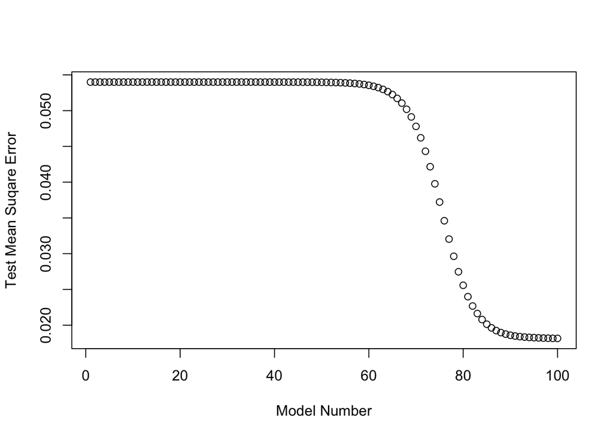

```r
x <- model.matrix(VioCrime ~ ., dat)[,-1]
y <- dat$VioCrime

# Set up the lambda grid
grid <- 10^seq(10, -2, length = 100)

# training and test data sets
set.seed(582038)
train <- sample(1:nrow(x), nrow(x)/2)
x.train <- x[train,]
y.train <- y[train]
x.test <- x[-train,]
y.test <- y[-train]
dat.glm.train <- dat[train,]
dat.glm.test <- dat[-train,]

# Run a ridge regression model on training data
ridge.mod <- glmnet(x.train, y.train, alpha = 0, lambda = grid, threst = 1e-12)

# Set up matrices to store the coefficients, predictions and errors
ridge.coeff <- matrix(0, nrow = ncol(x), ncol = 100)
ridge.pred <- matrix(0,nrow = length(y.test), ncol = 100)
testerr <- matrix(0, nrow = 100, ncol = 1)

#  Save values for 100 models
for (j in 1:100) {
  ridge.coeff[,j] <- ridge.mod$beta[,j]
  ridge.pred[,j] <- predict(ridge.mod, s = grid[j], newx = x.test)
  testerr[j] <- mean((ridge.pred[,j] - y.test)^2)
}

#  Plot the test MSEs for the 100 models
plot(testerr, xlab = "Model Number", ylab = "Test Mean Suqare Error")
```

```r
which.min(testerr)
```

```
## [1] 100
```

```r
# Find best lambda
lambda <- ridge.mod$lambda[100]
lambda
```

```
## [1] 0.01
```

```r
# Predict y for the test data
ridge.pred <- predict(ridge.mod, s = lambda, newx = x.test)

# Compute MSE and RMSE
mse.ridge <- mean((ridge.pred - y.test)^2)
mse.ridge
```

```
## [1] 0.01815556
```

```r
rmse.ridge <- mse.ridge^0.5
rmse.ridge
```

```
## [1] 0.1347426
```

- The MSE value is 0.01815556 and the RMSE value is 0.1347426.

**8. Now run cv.glmnet to perform cross validation on the training data using ridge regression. Note you do not need “grid” here, cv.glmnet chooses that automatically. Once again pick the best lambda from glmnet to fit a ridge regression model on the training data. Then predict y for the test data and compute MSE/RMSE.**

```r
# Cross Validation
ridge.mod2 <- cv.glmnet(x, y, alpha = 0)
lambda2 <- ridge.mod2$lambda.min

# Predict y for the test data
ridge.pred2 <- predict(ridge.mod, s = lambda2, newx = x.test)

# Compute MSE and RMSE
mse.ridge2 <- mean((ridge.pred2 - y.test)^2)
mse.ridge2
```

```
## [1] 0.01817913
```

```r
rmse.ridge2 <- mse.ridge2^0.5
rmse.ridge2
```

```
## [1] 0.13483
```

- The MSE value is 0.01817913 and the RMSE value is 0.13483.

**9. Repeat question 8 using LASSO.**

```r
# LASSO
lasso.mod <- glmnet(x.train, y.train, alpha = 1, lambda = grid, thresh = 1e-12)
lasso.mod2 <- cv.glmnet(x, y, alpha = 1)
lambda3 <- lasso.mod2$lambda.min

# Predict y for the test data
lasso.pred <- predict(lasso.mod, s = lambda3, newx = x.test)

# Compute MSE and RMSE
mse.lasso <- mean((lasso.pred - y.test)^2)
mse.lasso
```

```
## [1] 0.01821683
```

```r
rmse.lasso <- mse.lasso^0.5
rmse.lasso
```

```
## [1] 0.1349697
```

- The MSE value is 0.01821683 and the RMSE value is 0.1349697.

**10. Based on the work in questions 5-9, what is a “fair” estimate of the MSE/RMSE. Explain.**

```r
tab3 <- matrix(c(mse.train, rmse.train, mse.test, rmse.test, MSE, RMSE, MSE2, RMSE2, mse.ridge, rmse.ridge, mse.ridge2, rmse.ridge2, mse.lasso, rmse.lasso), ncol = 7, byrow = FALSE)
colnames(tab3) <- c("training", "test", "5-fold", "10-fold", "ridge(glmnet)", "ridge(cv.glmnet)", "LASSO")
rownames(tab3) <- c("MSE", "RMSE")
tab3
```

```
##        training test     5-fold    10-fold ridge(glmnet) ridge(cv.glmnet)
## MSE  0.01953796    0 0.02245597 0.02165972    0.01815556       0.01817913
## RMSE 0.13977825    0 0.14985317 0.14717243    0.13474258       0.13483000
##           LASSO
## MSE  0.01821683
## RMSE 0.13496972
```